# DA Yekun Layihə

Tamella Garibova

2026-07-17

# set up

```r
pacman::p_load(data.table,dplyr,readxl,widyr, writexl,readr,lubridate,httr,stringr,RODBC,RMariaDB,jsonlite,ssh,stringdist,reshape2,plotly,
               shiny,shinythemes,shinydashboard,shinyWidgets,knitr,forecast,rmarkdown,evaluate,base64enc,digest,highr,htmltools,xfun,yaml,mime,DT)
```

# Layihənin məqsədi

Bu layihənin məqsədi satış məlumatlarını analiz edərək məhsulların və satış nöqtələrinin performansını qiymətləndirmək, satış trendlərini müəyyən etmək, anomaliyaları aşkar etmək və əldə olunan nəticələr əsasında gələcək dövrlər üçün proqnoz və tövsiyələr hazırlamaqdır.

# 1-CI HISSE: *Datanın hazırlanması və təmizlənməsi*

## 1.1 Dataların R-ın yaddaşına İMPORT edilməsi

```r
fp_receipts <- readRDS("~/Downloads/fp_receipts.rds")
fp_map <- readRDS("~/Desktop/fp_map.rds")
setDT(fp_receipts)
setDT(fp_map)
```

## 1.2 İmpordun uğurlu olub-olmadığını görmək üçün ilk 10 sətri yoxlayırıq

```r
head(fp_receipts, 10)
```

```
##                                                    pos   rec_date rec_id
##                                                 <char>     <Date> <char>
##  1:                                     ?RZAQ MAGAZASI 2024-04-19  ?RZ_1
##  2:                                              APTEK 2024-04-19  APT_2
##  3:                                       BRAVO MARKET 2024-04-19  BRA_3
##  4:                                        ARAZ MARKET 2024-04-19  ARA_4
##  5:                                      BRAVO - OAZIS 2024-04-19  BRA_5
##  6:                                              BRAVO 2024-04-19  BRA_6
##  7: MCDONALDS-PARKBULVAR            (303 SAYLI MAĞAZA) 2024-04-19  MCD_7
##  8:                           OBA MAĞAZASI VƏ SUBİCARƏ 2024-04-19  OBA_8
##  9:                                             MAGAZA 2024-04-19  MAG_9
## 10:                    RAHAT MARKET METROPARK MAĞAZASI 2024-04-19 RAH_10
##                           product_name   qnt unit_price
##                                 <char> <num>      <num>
##  1: SULTAN BASMATI DUYU_1KQ*6 PET SISE     2       4.85
##  2:                      Sərbəst satış     2      21.87
##  3:                   PERWOLL GOLD 1L.     2       4.99
##  4:       BELARUS MOL.MIR SUD 2.5% 1LT     2       2.99
##  5:                A GOLD SOKOLAD 90Q.     2       2.45
##  6:                   PERWOLL QARA 1L.     2       4.99
##  7:                  McChicken O-Menyu     2       8.50
##  8:          BETA EARL GREY CAY 100 GR     2       3.15
##  9:              MILLA XAMA 25% 175 GR     2       2.95
## 10:                 AZCAKE BULKA QOZLU     2       1.80
```

```r
head(fp_map, 10)
```

```
##     period product_type                                  product profit_margin
##      <num>       <char>                                   <char>         <num>
##  1: 202403         FOOD   CHERNOGOLOVKA DUSES LIMONADI SB 0.5 LT          0.36
##  2: 202403         FOOD          PURE MILK OKUZ UREYI PENDIR 1KQ          0.32
##  3: 202403         FOOD                 FRENCH COW KERE YAGI 1KQ          0.15
##  4: 202403     NON-FOOD              UNIVERSAL CLEANER XIMCISTKA          0.50
##  5: 202403         FOOD                     KISHMISH QIZILI B KQ          0.39
##  6: 202403         FOOD    KOTEX NATURAL HIPOALERGEN NORMAL 7X16          0.24
##  7: 202403         FOOD MOLPED GIG BEZ ULTRA NORMAL QANADLI 12ED          0.24
##  8: 202403         FOOD             SUN SALFET 25X25 CM 300 EDED          0.27
##  9: 202403         FOOD            KRAB CUBUQLARI KRABIYA 100 QR          0.37
## 10: 202403         FOOD                            PUL BIBER 50G          0.25
```

## 1.3 Hər iki datanın kolon adlarını və statistik xülasəsini yoxlayırıq

```r
colnames(fp_receipts)
```

```
## [1] "pos"          "rec_date"     "rec_id"       "product_name" "qnt"
## [6] "unit_price"
```

```r
colnames(fp_map)
```

```
## [1] "period"        "product_type"  "product"       "profit_margin"
```

```r
summary(fp_receipts)
```

```
##      pos               rec_date             rec_id          product_name
##  Length:10000909    Min.   :2024-04-19   Length:10000909    Length:10000909
##  Class :character   1st Qu.:2024-04-21   Class :character   Class :character
##  Mode  :character   Median :2024-04-29   Mode  :character   Mode  :character
##                     Mean   :2024-05-03
##                     3rd Qu.:2024-05-16
##                     Max.   :2024-05-31
##       qnt             unit_price
##  Min.   :1.00e+00   Min.   :     1.00
##  1st Qu.:2.00e+00   1st Qu.:     1.80
##  Median :2.00e+00   Median :     2.80
##  Mean   :3.69e+00   Mean   :     6.15
##  3rd Qu.:2.00e+00   3rd Qu.:     4.99
##  Max.   :3.00e+05   Max.   :132301.00
```

```r
summary(fp_map)
```

```
##      period       product_type         product          profit_margin
##  Min.   :202403   Length:118118      Length:118118      Min.   :-99.9600
##  1st Qu.:202403   Class :character   Class :character   1st Qu.:  0.2600
##  Median :202404   Mode  :character   Mode  :character   Median :  0.3400
##  Mean   :202404                                         Mean   :  0.3124
##  3rd Qu.:202405                                         3rd Qu.:  0.4300
##  Max.   :202405                                         Max.   :100.0900
```

## 1.4 Mətn xetalarını və simvolları təmizləmək üçün funksiyalar yaradırıq.

```r
            library(stringr)

# 1. Mətn nizamlanması funksiyası (Böyük hərf və boşluqların təmizlənməsi)
metn_nizama_sal <- function(x) {
  x <- str_to_upper(x)   # Mötərizənin içinə 'x' əlavə edildi
  x <- str_squish(x)     # Mötərizənin içinə 'x' əlavə edildi
  return(x)
}

# 2. Hərf xətalarının düzəldilməsi və unifikasiya funksiyası
herf_xetalarini_duzelt <- function(x) {
  # 1. Sözün əvvəlində və ya içində olan həqiqi sual işarələrini (?) birbaşa E hərfi ilə əvəz edirik
  x <- gsub("\\?", "E", x) # Regex escape forması düzəldildi

  # 2. Azərbaycan hərflərini ingilis variantına unifikasiya edirik
  x <- gsub("Ə", "E", x, fixed = TRUE)
  x <- gsub("Ğ", "G", x, fixed = TRUE)
  x <- gsub("İ", "I", x, fixed = TRUE)
  x <- gsub("Ö", "O", x, fixed = TRUE)
  x <- gsub("Ü", "U", x, fixed = TRUE)
  x <- gsub("Ş", "S", x, fixed = TRUE)
  x <- gsub("Ç", "C", x, fixed = TRUE)

  return(x)
}
```

## 1.5 fp_receipts daxilində period və təmizlənmiş məhsul adı sütunlarını birbaşa yaradırıq

```r
# 1. Period sütununun yaradılması
fp_receipts[, period := year(rec_date) * 100 + month(rec_date)]

# 2. POS, REC_ID və Product Name sütunlarının yerindəcə (in-place) təmizlənməsi
fp_receipts[, pos := herf_xetalarini_duzelt(metn_nizama_sal(pos))]
fp_receipts[, rec_id := herf_xetalarini_duzelt(metn_nizama_sal(rec_id))]

# 3. Təmizlənmiş məhsul adı üçün yeni sütun yaradılması
fp_receipts[, product_name_clean := herf_xetalarini_duzelt(metn_nizama_sal(str_replace_all(product_name, "['\\\\.']", "")))]
```

**Şərh:** fp_receipts cədvəlinə analiz üçün period sütunu yaradılır. Məhsul adları standartlaşdırılaraq bütün hərflər böyük yazılır, nöqtə və dırnaq işarələri silinir, artıq boşluqlar isə aradan qaldırılır.

## 1.6 fp_map cədvəli təmizlənir.Təkrarlanan sətirlər aradan qaldırılır, product sütunundakı lazımsız simvollar silinir ki, join əməliyyatı daha dəqiq nəticə versin.Sonra təkrarlanan sətirləri qruplaşdırıb ortalama marjanı tapırıq

```r
fp_map_clean <- fp_map %>%
  mutate(product_clean = herf_xetalarini_duzelt(metn_nizama_sal(str_replace_all(product, "['\\\\.']", "")))) %>%
  group_by(product_clean, period, product_type) %>%
  summarise(profit_margin = mean(profit_margin, na.rm = TRUE), .groups = 'drop')
```

## 1.7 fp_receipts_clean və fp_map_clean cədvəlləri ortaq açarlar (product_name_clean və period) əsasında left_join() funksiyası ilə birləşdirilir.

```r
esas_data <- left_join(fp_receipts, fp_map_clean,
                       by = c("product_name_clean" = "product_clean", "period" = "period"))
```

## 1.8 Gelir ve menfeet sutunlarini yaradiram,NA deyerleri ve Data strukturunu yoxlayiram.

```r
esas_data <- esas_data %>%
  mutate(
    gelir = qnt * unit_price,
    menfeet = gelir * profit_margin
  )
fp_profit = esas_data %>% filter(!is.na(profit_margin))
str(esas_data)
```

```
## Classes 'data.table' and 'data.frame':   10000909 obs. of  12 variables:
##  $ pos               : chr  "ERZAQ MAGAZASI" "APTEK" "BRAVO MARKET" "ARAZ MARKET" ...
##  $ rec_date          : Date, format: "2024-04-19" "2024-04-19" ...
##  $ rec_id            : chr  "ERZ_1" "APT_2" "BRA_3" "ARA_4" ...
##  $ product_name      : chr  "SULTAN BASMATI DUYU_1KQ*6 PET SISE" "Sərbəst satış" "PERWOLL GOLD 1L." "BELARUS MOL.MIR SUD 2.5% 1LT" ...
##  $ qnt               : num  2 2 2 2 2 2 2 2 2 2 ...
##  $ unit_price        : num  4.85 21.87 4.99 2.99 2.45 ...
##  $ period            : num  202404 202404 202404 202404 202404 ...
##  $ product_name_clean: chr  "SULTAN BASMATI DUYU_1KQ*6 PET SISE" "SERBEST SATIS" "PERWOLL GOLD 1L" "BELARUS MOLMIR SUD 25% 1LT" ...
##  $ product_type      : chr  NA NA "FOOD" NA ...
##  $ profit_margin     : num  NA NA 0.58 NA NA NA NA NA NA NA ...
##  $ gelir             : num  9.7 43.74 9.98 5.98 4.9 ...
##  $ menfeet           : num  NA NA 5.79 NA NA ...
##  - attr(*, ".internal.selfref")=<externalptr>
```

```r
summary(esas_data)
```

```
##      pos               rec_date             rec_id          product_name
##  Length:10000909    Min.   :2024-04-19   Length:10000909    Length:10000909
##  Class :character   1st Qu.:2024-04-21   Class :character   Class :character
##  Mode  :character   Median :2024-04-29   Mode  :character   Mode  :character
##                     Mean   :2024-05-03
##                     3rd Qu.:2024-05-16
##                     Max.   :2024-05-31
##
##       qnt             unit_price            period       product_name_clean
##  Min.   :1.00e+00   Min.   :     1.00   Min.   :202404   Length:10000909
##  1st Qu.:2.00e+00   1st Qu.:     1.80   1st Qu.:202404   Class :character
##  Median :2.00e+00   Median :     2.80   Median :202404   Mode  :character
##  Mean   :3.69e+00   Mean   :     6.15   Mean   :202404
##  3rd Qu.:2.00e+00   3rd Qu.:     4.99   3rd Qu.:202405
##  Max.   :3.00e+05   Max.   :132301.00   Max.   :202405
##
##  product_type       profit_margin         gelir              menfeet
##  Length:10000909    Min.   :-9        Min.   :     1.00   Min.   : -76
##  Class :character   1st Qu.: 0        1st Qu.:     4.10   1st Qu.:   1
##  Mode  :character   Median : 0        Median :     6.20   Median :   1
##                     Mean   : 0        Mean   :    14.43   Mean   :   2
##                     3rd Qu.: 0        3rd Qu.:    10.08   3rd Qu.:   2
##                     Max.   : 1        Max.   :303001.01   Max.   :1121
##                     NA's   :9583255                       NA's   :9583255
```

**Şərh:** Satış məbləği məhsul miqdarı ilə vahid qiymətin hasilinə əsasən, mənfəət isə satış məbləği ilə mənfəət marjasının hasilinə əsasən hesablanmışdır. Mənfəət təhlilləri üçün `profit_margin` dəyəri mövcud olan sətirlər ayrıca `fp_profit` obyektində saxlanılmışdır.

## 1.9 Məhsul tipində təsnifat probleminin yoxlanılması

```r
table(esas_data$product_type, useNA = "ifany")
```

```
##
##     FOOD NON-FOOD     <NA>
##   413334     4320  9583255
```

**Şərh:** Product_type sütununun analizi göstərir ki, ümumi 10 milyondan çox sətrin 95.8%-i (9,583,255 sətir) boşdur (NA). Mövcud dolu datada isə kəskin disbalans (FOOD: 99%, NON-FOOD: 1%) müşahidə olunur. Bu sütunun mövcud vəziyyətdə təsnifat modelində və ya statistik analizlərdə istifadəsi etibarlı nəticələr verməyəcək. Qeyd: Boşluqlarla yanaşı, datada ciddi etiketləmə xətaları da aşkarlanmışdır. Belə ki, qeyri-qida kateqoriyasına aid olan ARKO SABUN, BINGO YUYUCU TOZ,BLADE DEO,DF ROSE MENDIL, ABC TƏMİZLƏYİCİ KREM, ALAFRAN XLOR kimi məhsullar sistemdə səhvən FOOD kateqoriyasında qeyd olunmuşdur. Həm kütləvi boşluqlar, həm də bu tip yanlış təsnifat xətaları səbəbindən bu sütunun mövcud vəziyyətdə təsnifat modelində və ya hər hansı statistik analizdə istifadəsi etibarlı nəticələr verməyəcək.

## 1.10 Mənfəət marjasının mövcudluğu

```r
marja_yoxlanis <- data.frame(
  Status = c("Məlumat Var", "Məlumat Yoxdur"),
  Satis_Sayi = c(sum(!is.na(esas_data$profit_margin)), sum(is.na(esas_data$profit_margin)))
)
datatable(marja_yoxlanis)
```

|  | Status | Satis_Sayi |
| --- | --- | --- |
| 1 | Məlumat Var | 417654 |
| 2 | Məlumat Yoxdur | 9583255 |

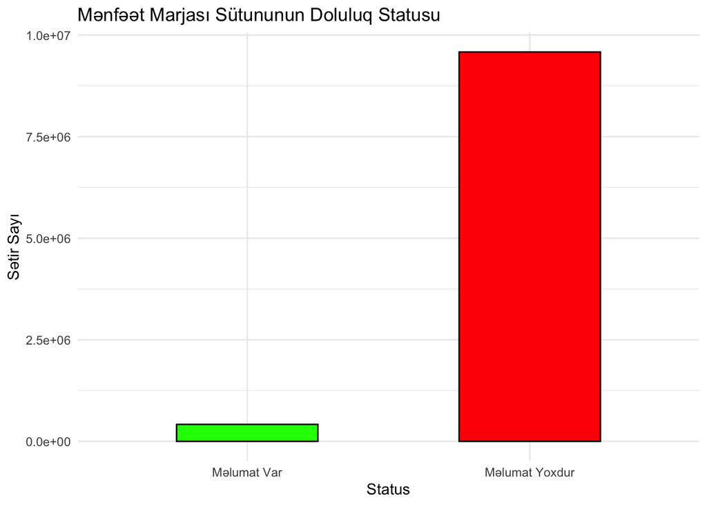

```r
ggplot(marja_yoxlanis, aes(x = Status, y = Satis_Sayi, fill = Status)) +
  geom_col(width = 0.5, color = "black") +
  scale_fill_manual(values = c("Məlumat Var" = "green", "Məlumat Yoxdur" = "red")) +
  theme_minimal() +
  theme(legend.position = "none") +
  labs(
    title = "Mənfəət Marjası Sütununun Doluluq Statusu",
    x = "Status",
    y = "Sətir Sayı"
  )
```

**Şərh:** Sektorlar üzrə mənfəətlilik təhlilinə keçməzdən əvvəl, analizin dürüstlüyünü təmin etmək üçün datamızda yer alan profit_margin sütunundakı məlumatların doluluq səviyyəsini (bax qeyd edilmiş NA dəyərlərini) yoxlayırıq. Bu, bizə hesablama apararkən nə qədər tranzaksiyanı əhatə edə biləcəyimizi göstərir. Yuxarıdakı cədvəl və qrafikdən göründüyü kimi, tranzaksiyaların böyük bir hissəsində mənfəət marjası məlumatı yoxdur. Bu analiz bizə növbəti mərhələdə sektorlar üzrə mənfəət marjası hesablayarkən datanın nə dərəcədə etibarlı olduğunu anlamağa kömək edir.

## 1.11 Mənfəət Göstəricilərindəki Boşluqların POS-lar üzrə Paylanması

```r
esas_data %>%
 group_by(pos) %>%
  summarise(
    Məlumat_Var = sum(!is.na(profit_margin)),
    Məlumat_Yoxdur = sum(is.na(profit_margin))
  )
```

```
## # A tibble: 4,267 × 3
##    pos                                               Məlumat_Var Məlumat_Yoxdur
##    <chr>                                                   <int>          <int>
##  1 "\"\" BIZIM MARKET \"\""                                    0            554
##  2 "\"\" FERAH \"\" ECZACILIQ MEHSULLARIN SATISI"              0             18
##  3 "\"\" PAYIZ-74 \"\" MARKET"                                 0           1236
##  4 "\"\"1001 ERZAQ\"\" MAGAZASI"                               0            159
##  5 "\"\"24 SAAT\"\" MARKET"                                    3            412
##  6 "\"\"28 MALL\"\" TICARET MERKEZI PASA INSAAT MMC"           0             14
##  7 "\"\"ABSERON\"\" MARKET"                                    1            773
##  8 "\"\"AKABE INSAAT\"\" TICARET OBYEKTI"                      0              7
##  9 "\"\"ALBATROS 5\"\" GEYIM MAGAZASI"                         0              1
## 10 "\"\"ALDO ACCESSORIES\"\" CANTA MAGAZASI"                   0             42
## # ℹ 4,257 more rows
```

## 1.12 Boşluqların Biznes Sektorları üzrə Paylanması

```r
# Sektorlar üzrə doluluq payını yoxlayırıq
sektor_doluluq <- esas_data %>%
  mutate(
    pos_böyük = toupper(pos),
    Sektor = case_when(
      str_detect(pos_böyük, "BRAVO|BAZARSTORE|MARKET|STORE|MAGAZA") ~ "Supermarketlər",
      str_detect(pos_böyük, "APTEK|PHARMACY") ~ "Apteklər (Səhiyyə)",
      str_detect(pos_böyük, "XESTEXANA|KLINIKA|HOSPITAL") ~ "Xəstəxanalar (Tibb)",
      str_detect(pos_böyük, "ANBAR|WAREHOUSE") ~ "B2B / Anbar",
      TRUE ~ "Digər Satış Nöqtələri"
    )
  ) %>%
  group_by(Sektor) %>%
  summarise(
    Məlumat_Var = sum(!is.na(profit_margin)),
    Məlumat_Yoxdur = sum(is.na(profit_margin))
  )

datatable(sektor_doluluq)
```

|  | Sektor | Məlumat_Var | Məlumat_Yoxdur |
| --- | --- | --- | --- |
| 1 | Apteklər (Səhiyyə) | 6 | 518177 |
| 2 | B2B / Anbar | 4 | 35478 |
| 3 | Digər Satış Nöqtələri | 9308 | 853628 |
| 4 | Supermarketlər | 408336 | 8159111 |
| 5 | Xəstəxanalar (Tibb) | 0 | 16861 |

**Şərh:** Datadakı mənfəət marjası boşluqları fərdi mağazalarla məhdudlaşmır, bütün biznes sektorlarını əhatə edən kütləvi və sistemli bir problemdir. Şirkətin əsas hərəkətverici qüvvəsi olan Supermarketlər sektorunda məlumatların 95%-dən çoxunun boş olması ümumi gəlirlilik analizini ciddi şəkildə məhdudlaşdırır. Vəziyyət Apteklər və Xəstəxanalar kimi tibb sahələrində daha kritikdir, çünki burada doluluq dərəcəsi demək olar ki, 0% səviyyəsindədir. Anbar kimi digər sektorlarda mövcud olan cəmi 4 sətirlik az sayda məlumat isə bütün biznes istiqamətini düzgün təmsil edə bilmir və bizi yanlış nəticələrə apara bilər. Bütövlükdə bu kütləvi boşluqlar maliyyə hesabatlılığına və real-vaxt analizlərinə birbaşa mənfi təsir göstərdiyi üçün mütləq IT və Kateqoriya şöbələri ilə birlikdə sistem səviyyəsində araşdırılmalı və bərpa edilməlidir.

## 1.13 Esas dataya baxış

```r
dim(esas_data)
```

```
## [1] 10000909       12
```

```r
str(esas_data)
```

```
## Classes 'data.table' and 'data.frame':   10000909 obs. of  12 variables:
##  $ pos               : chr  "ERZAQ MAGAZASI" "APTEK" "BRAVO MARKET" "ARAZ MARKET" ...
##  $ rec_date          : Date, format: "2024-04-19" "2024-04-19" ...
##  $ rec_id            : chr  "ERZ_1" "APT_2" "BRA_3" "ARA_4" ...
##  $ product_name      : chr  "SULTAN BASMATI DUYU_1KQ*6 PET SISE" "Sərbəst satış" "PERWOLL GOLD 1L." "BELARUS MOL.MIR SUD 2.5% 1LT" ...
##  $ qnt               : num  2 2 2 2 2 2 2 2 2 2 ...
##  $ unit_price        : num  4.85 21.87 4.99 2.99 2.45 ...
##  $ period            : num  202404 202404 202404 202404 202404 ...
##  $ product_name_clean: chr  "SULTAN BASMATI DUYU_1KQ*6 PET SISE" "SERBEST SATIS" "PERWOLL GOLD 1L" "BELARUS MOLMIR SUD 25% 1LT" ...
##  $ product_type      : chr  NA NA "FOOD" NA ...
##  $ profit_margin     : num  NA NA 0.58 NA NA NA NA NA NA NA ...
##  $ gelir             : num  9.7 43.74 9.98 5.98 4.9 ...
##  $ menfeet           : num  NA NA 5.79 NA NA ...
##  - attr(*, ".internal.selfref")=<externalptr>
```

```r
summary(esas_data)
```

```
##      pos               rec_date             rec_id          product_name
##  Length:10000909    Min.   :2024-04-19   Length:10000909    Length:10000909
##  Class :character   1st Qu.:2024-04-21   Class :character   Class :character
##  Mode  :character   Median :2024-04-29   Mode  :character   Mode  :character
##                     Mean   :2024-05-03
##                     3rd Qu.:2024-05-16
##                     Max.   :2024-05-31
##
##       qnt             unit_price            period       product_name_clean
##  Min.   :1.00e+00   Min.   :     1.00   Min.   :202404   Length:10000909
##  1st Qu.:2.00e+00   1st Qu.:     1.80   1st Qu.:202404   Class :character
##  Median :2.00e+00   Median :     2.80   Median :202404   Mode  :character
##  Mean   :3.69e+00   Mean   :     6.15   Mean   :202404
##  3rd Qu.:2.00e+00   3rd Qu.:     4.99   3rd Qu.:202405
##  Max.   :3.00e+05   Max.   :132301.00   Max.   :202405
##
##  product_type       profit_margin         gelir              menfeet
##  Length:10000909    Min.   :-9        Min.   :     1.00   Min.   : -76
##  Class :character   1st Qu.: 0        1st Qu.:     4.10   1st Qu.:   1
##  Mode  :character   Median : 0        Median :     6.20   Median :   1
##                     Mean   : 0        Mean   :    14.43   Mean   :   2
##                     3rd Qu.: 0        3rd Qu.:    10.08   3rd Qu.:   2
##                     Max.   : 1        Max.   :303001.01   Max.   :1121
##                     NA's   :9583255                       NA's   :9583255
```

# 2-CI HISSE: *Deskriptiv təhlil*

### Datanın daxilindəki əsas meyllər, ən çox qazanc gətirən məhsullar, aparıcı satış məntəqələri və alıcı vərdişləri analiz olunur. Müəyyən edilmiş nəticələr isə daha sonra qrafiklər köməyilə vizual formada təqdim edilir.

## 2.1 Məlumat ölçüləri və əsas göstəricilər

```r
dim(esas_data)
```

```
## [1] 10000909       12
```

```r
dim(fp_profit)
```

```
## [1] 417654     12
```

```r
summary(esas_data$gelir)
```

```
##      Min.   1st Qu.    Median      Mean   3rd Qu.      Max.
##      1.00      4.10      6.20     14.43     10.08 303001.01
```

```r
summary(esas_data$qnt)
```

```
##     Min.  1st Qu.   Median     Mean  3rd Qu.     Max.
## 1.00e+00 2.00e+00 2.00e+00 3.69e+00 2.00e+00 3.00e+05
```

```r
summary(fp_profit$profit_margin)
```

```
##    Min. 1st Qu.  Median    Mean 3rd Qu.    Max.
## -9.4700  0.1600  0.2200  0.2357  0.2700  1.1000
```

```r
summary(fp_profit$menfeet)
```

```
##     Min.  1st Qu.   Median     Mean  3rd Qu.     Max.
##  -76.162    0.940    1.325    1.835    1.939 1120.671
```

## 2.2 Qiymət Aralıqlarına Görə Satış Performansı

Malları ucuz (0-5 AZN), orta (5-50 AZN) və bahalı (50+ AZN) qruplara bölüb, hansı qiymətdə olan malların ümumilikdə daha çox gəlir gətirdiyini tapırıq.

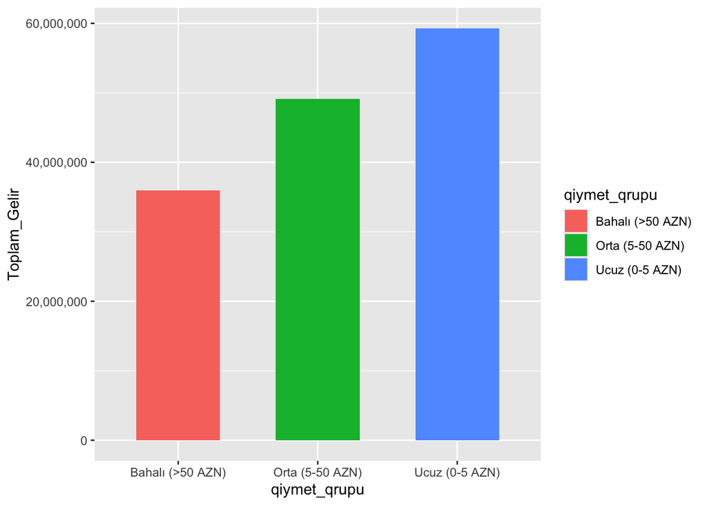

```r
# 1. Qiymət qruplarının sadə formada bölünməsi
qiymet_seqmentleri <- esas_data %>%
  mutate(qiymet_qrupu = case_when(
    unit_price <= 5  ~ "Ucuz (0-5 AZN)",
    unit_price > 5 & unit_price <= 50 ~ "Orta (5-50 AZN)",
    unit_price > 50 ~ "Bahalı (>50 AZN)"
  )) %>%
  group_by(qiymet_qrupu) %>%
  summarise(Toplam_Gelir = sum(gelir, na.rm = TRUE))
ggplot(qiymet_seqmentleri, aes(x = qiymet_qrupu, y = Toplam_Gelir, fill = qiymet_qrupu)) +
  geom_col(width = 0.6) +scale_y_continuous(labels=scales::comma)
```

```r
  theme_minimal() +
  labs(
    title = "Qiymət Seqmentlərinin Gəlir Payı",
    x = "Qiymət Kateqoriyası",
    y = "Toplam Gəlir (AZN)"
  )
```

[output not shown]

[output cut: 299 more lines]

[output not shown]

**Şərh:** Məhsulların qiymət aralıqlarına görə gəlir payını analiz etdikdə müəyyən olunur ki, şirkətə ən çox qazanc gətirən sahə qiyməti 0-5 AZN arasında dəyişən ucuz kateqoriyalı mallardır (təxminən 60 milyon AZN). Qiyməti 5-50 AZN olan orta seqment məhsulları da gəlirdə ciddi paya sahib olsa da, 50 AZN-dən baha olan premium məhsulların ümumi gəlirə töhfəsi ən aşağı səviyyədədir. Bu nəticə bizə göstərir ki, biznesimizin əsas gəlir modelinin hərəkətverici qüvvəsi baha məhsullar satmaq deyil, ucuz və sürətli dövriyyəyə malik (high-volume) gündəlik tələbat mallarının kütləvi satışıdır.

## 2.3 Səbətləri məbləğlərinə görə kateqoriyalara ayırırıq

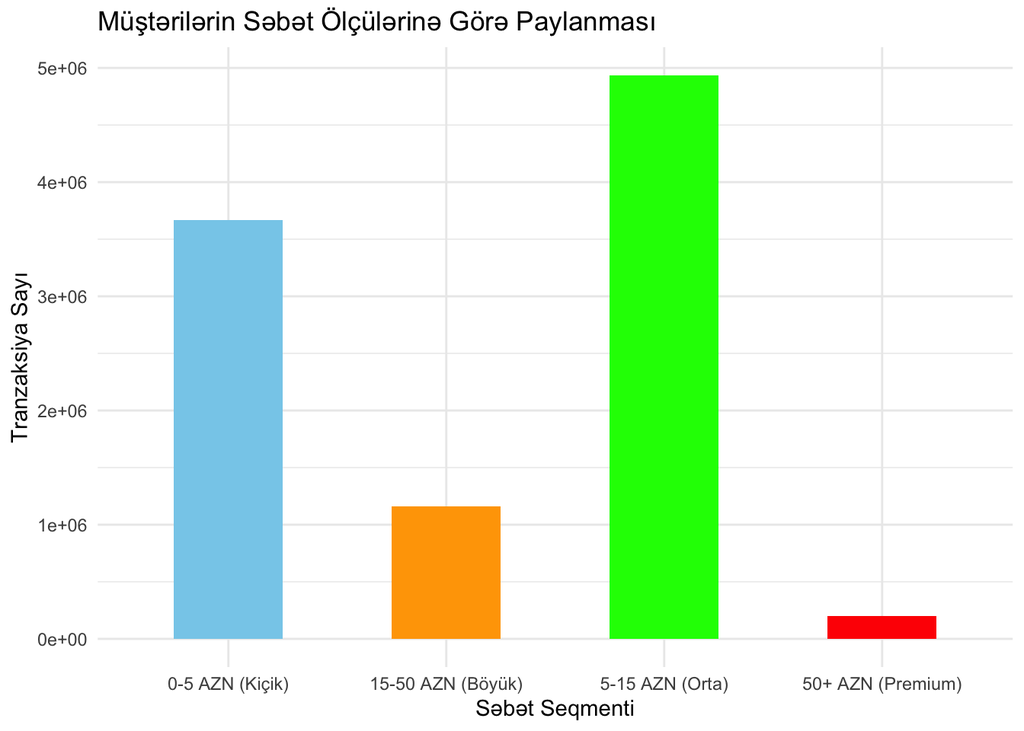

```r
sebet_analizi <- esas_data %>%
  filter(gelir > 0 & gelir <= 300) %>% # Anomaliyaları kənarlaşdırırıq
  mutate(Sebet_Tipi = case_when(
    gelir <= 5  ~ "0-5 AZN (Kiçik)",
    gelir <= 15 ~ "5-15 AZN (Orta)",
    gelir <= 50 ~ "15-50 AZN (Böyük)",
    TRUE        ~ "50+ AZN (Premium)"
  )) %>%
  group_by(Sebet_Tipi) %>%
  summarise(Tranzaksiya_Sayi = n())

# 2. Rəngli və peşəkar sütun qrafiki qururuq
ggplot(sebet_analizi, aes(x = Sebet_Tipi, y = Tranzaksiya_Sayi, fill = Sebet_Tipi)) +
  geom_col( width = 0.5) +
  scale_fill_manual(values = c("0-5 AZN (Kiçik)" = "skyblue",
                               "5-15 AZN (Orta)" = "green",
                               "15-50 AZN (Böyük)" = "orange",
                               "50+ AZN (Premium)" = "red")) +
  theme_minimal() +
  labs(
    title = "Müştərilərin Səbət Ölçülərinə Görə Paylanması",
    x = "Səbət Seqmenti",
    y = "Tranzaksiya Sayı"
  ) +
  theme(legend.position = "none")
```

## 2.4 Miqdarca ən çox satılan top 10 məhsul və xidmətin müəyyən edilməsi

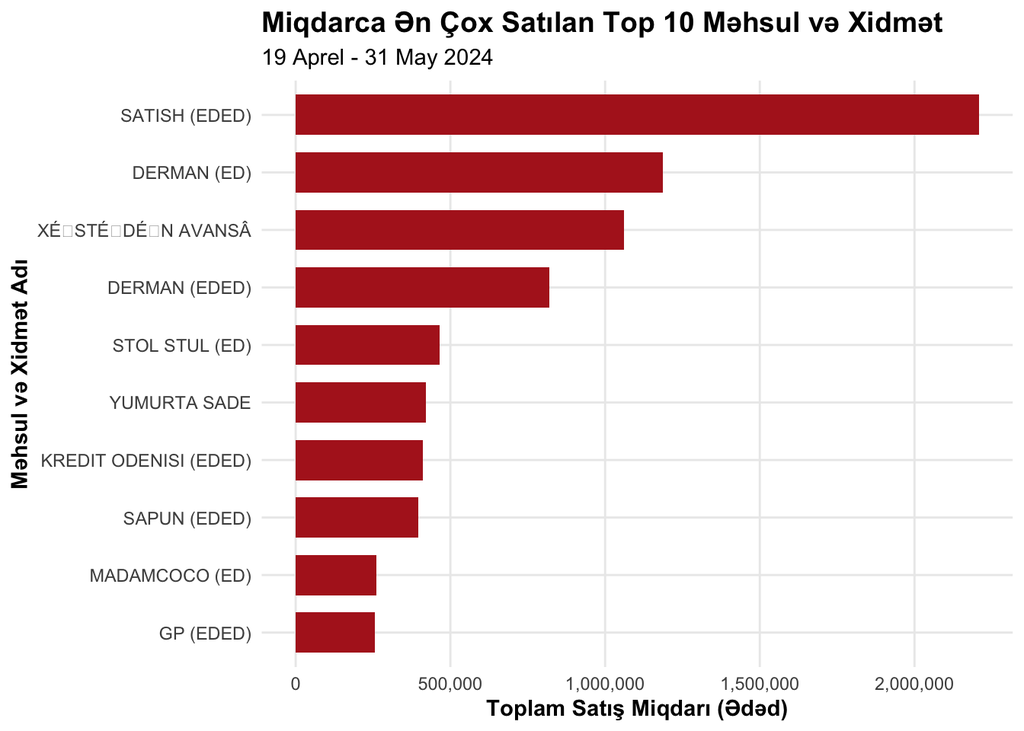

```r
top10_products <- esas_data %>%
  group_by(product_name_clean) %>%
  summarise(Total_Quantity = sum(qnt, na.rm = TRUE)) %>%
  arrange(desc(Total_Quantity)) %>%
  slice_max(Total_Quantity, n = 10)

ggplot(top10_products, aes(x = reorder(product_name_clean, Total_Quantity), y = Total_Quantity)) +
  geom_col(fill = "firebrick", width = 0.7) +
  coord_flip() +
  scale_y_continuous(labels = scales::comma) +
  theme_minimal() +
  labs(
    title = "Miqdarca Ən Çox Satılan Top 10 Məhsul və Xidmət ",
    subtitle = "19 Aprel - 31 May 2024",
    x = "Məhsul və Xidmət Adı",
    y = "Toplam Satış Miqdarı (Ədəd)"
  ) +
  theme(
    plot.title = element_text(face = "bold", size = 14),
    axis.title = element_text(face = "bold"),
    panel.grid.minor = element_blank()
  )
```

**Şərh:** Qrafikdən göründüyü kimi, 2 milyondan çox miqdarla birinci yerdə ümumi “Satış (Ədəd)” qeydi dayanır ki, bu da konkret kateqoriyası qeyd edilmədən sistemə birbaşa pərakəndə olaraq vurulan əməliyyatları ifadə edir. Siyahıda ikinci və dördüncü yerləri “Dərman” kateqoriyasının tutması şəbəkə daxilində əczaçılıq və tibb məhsullarının dövriyyəsinin yüksək olduğunu göstərir. “Xəstədən Avans” və “Kredit ödənişi” kimi sırf maliyyə xidmətlərinin də miqdarca ilk onluğa düşməsi pərakəndə satış sistemində həm xidmət, həm də nağdsız/avans əməliyyatlarının əhəmiyyətli paya sahib olduğunu sübut edir. Fiziki məhsullar arasında isə kütləvi gündəlik tələbat mallarından olan “Yumurta sadə”, “Sabun” və “Stol stul” kimi məhsullar miqdar baxımından ən aktiv dövriyyədə olanlar sırasındadır. Aparılan deskriptiv təhlildən yola çıxaraq, gələcəkdə həm biznes fəaliyyətini optimallaşdırmaq, həm də məlumatların keyfiyyətini artırmaq üçün iki mühüm strateji addım tövsiyə olunur. Birincisi, sistemdə miqdarca ən öndə gedən “Satış (Ədəd)” kimi ümumi qeydlərin gələcəkdə azaldılması və hər bir satışın konkret məhsul kartına bağlanması şərtdir ki, bu da anbar və çeşid idarəetməsini daha dəqiq etməyə imkan verəcək. İkincisi isə, “Xəstədən Avans” və “Kredit ödənişi” kimi sırf maliyyə əməliyyatlarının kütləvi pərakəndə satış daxilində çox böyük paya sahib olduğunu nəzərə alaraq, xidmət nöqtələrində növbələrin qarşısını almaq üçün bu xidmətləri rəqəmsal platformalara, özünəxidmət terminallarına köçürmək və ya kassa nöqtələrində pərakəndə satış ilə maliyyə əməliyyatlarını fiziki olaraq bir-birindən ayırmaq müştəri məmnuniyyətini və xidmət sürətini ciddi şəkildə artıra bilər.

## 2.5 Ən çox gəlir gətirən top 10 məhsul və xidməti tapırıq

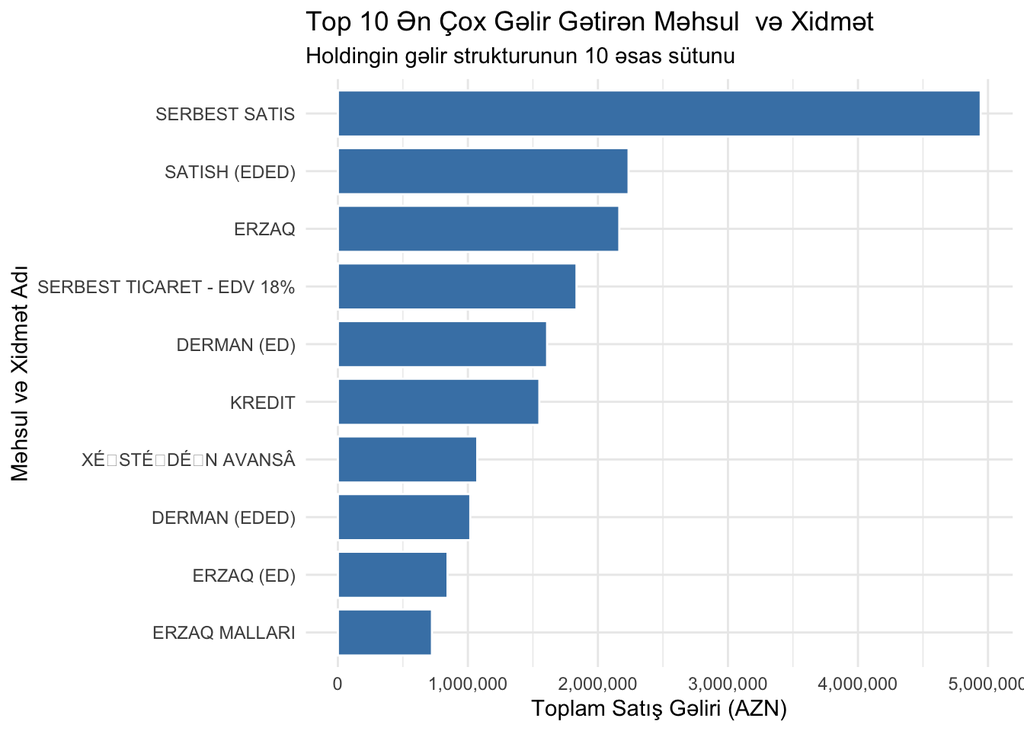

```r
top10_mehsul <- esas_data %>%
  group_by(product_name_clean) %>%
  summarise(Toplam_Gelir = sum(gelir, na.rm = TRUE)) %>%
  arrange(desc(Toplam_Gelir)) %>%
  slice_head(n = 10)
ggplot(top10_mehsul, aes(x = reorder(product_name_clean, Toplam_Gelir), y = Toplam_Gelir)) +
  geom_col(fill = "steelblue", color = "white", width = 0.8) +
  coord_flip() +
  scale_y_continuous(labels = scales::comma) +
  theme_minimal() +
  labs(
    title = "Top 10 Ən Çox Gəlir Gətirən Məhsul  və Xidmət",
    subtitle = "Holdingin gəlir strukturunun 10 əsas sütunu",
    x = "Məhsul və Xidmət Adı",
    y = "Toplam Satış Gəliri (AZN)"
  )
```

## 2.6 Ən çox gəlir gətirən top 10 satış nöqtəsinin tapılması

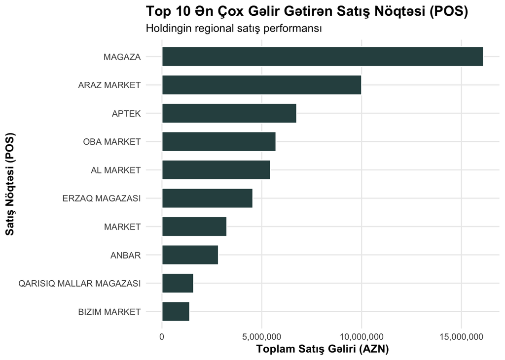

```r
top10_pos <- esas_data %>%
  group_by(pos) %>%
  summarise(Toplam_Gelir = sum(gelir, na.rm = TRUE)) %>%
  arrange(desc(Toplam_Gelir)) %>%
  slice_head(n = 10)

ggplot(top10_pos, aes(x = reorder(pos, Toplam_Gelir), y = Toplam_Gelir)) +
  geom_col(fill = "darkslategray", color = "white", width = 0.7) +
  coord_flip() +
  scale_y_continuous(labels = scales::comma) +
  theme_minimal() +
  labs(
    title = "Top 10 Ən Çox Gəlir Gətirən Satış Nöqtəsi (POS)",
    subtitle = "Holdingin regional satış performansı",
    x = "Satış Nöqtəsi (POS)",
    y = "Toplam Satış Gəliri (AZN)"
  ) +
  theme(
    plot.title = element_text(face = "bold", size = 14),
    axis.title = element_text(face = "bold"),
    panel.grid.minor = element_blank()
  )
```

**Şərh:** Satış nöqtələrinin gəlir təhlili göstərir ki, holdingin ən çox qazanc gətirən mərkəzi təxminən 16 milyon AZN gəlirlə “MAĞAZA” adlı bölmədir. İkinci yerdə 10 milyon AZN-ə yaxın dövriyyə ilə “ARAZ MARKET”, üçüncü yerdə isə təxminən 6.5 milyon AZN gəlirlə “APTEK” qərarlaşıb. Burada diqqət çəkən əsas məqam odur ki, ARAZ, OBA və AL kimi adlar holdingin daxilindəki konkret brendi və xüsusi idarəetməsi olan supermarket şəbəkələridir. Liderlikdə dayanan “MAĞAZA” isə heç bir böyük şəbəkəyə aid olmayan, geyim, qab-qacaq kimi qeyri-ərzaq satışı edən digər satış nöqtələrinin və ya sistemdə adı ümumi qeyd edilmiş kassaların cəmidir. Gələcək biznes fəaliyyəti üçün məsləhət kimi qeyd etmək olar ki, birinci yerdə gələn “MAĞAZA” və yeddinci yerdəki “MARKET” kimi ümumi adlar sistemdə mütləq konkret filial adlarına və ya ünvanlarına bölünməlidir. Çünki 16 milyon AZN kimi nəhəng bir gəlirin tam olaraq hansı nöqtələrdən gəldiyini dəqiq bilmək daxili nəzarət və gələcək investisiya qərarları üçün çox vacibdir. Eyni zamanda, “APTEK” və “ARAZ MARKET” kimi ən çox pul gətirən sahələrin uğurlu satış taktikalarını və çeşid idarəetməsini digər market və mağazalarımızda da tətbiq etməklə ümumi gəlirliliyimizi daha da artıra bilərik.

## 2.7 Orta Çek və Səbət Paylanması Analizi

```r
# 1. Hər bir unikal qəbzin (rec_id) toplam məbləğini hesablayırıq
receipt_sums <- esas_data %>%
  group_by(rec_id) %>%
  summarise(Total_Receipt_Value = sum(gelir, na.rm = TRUE))

average_ticket_size <- mean(receipt_sums$Total_Receipt_Value, na.rm = TRUE)
median_ticket_size <- median(receipt_sums$Total_Receipt_Value, na.rm = TRUE)

print(paste("Orta Çek Dəyəri (Mean):", round(average_ticket_size, 2), "AZN"))
```

```
## [1] "Orta Çek Dəyəri (Mean): 14.43 AZN"
```

```r
print(paste("Median Çek Dəyəri (Median):", round(median_ticket_size, 2), "AZN"))
```

```
## [1] "Median Çek Dəyəri (Median): 6.2 AZN"
```

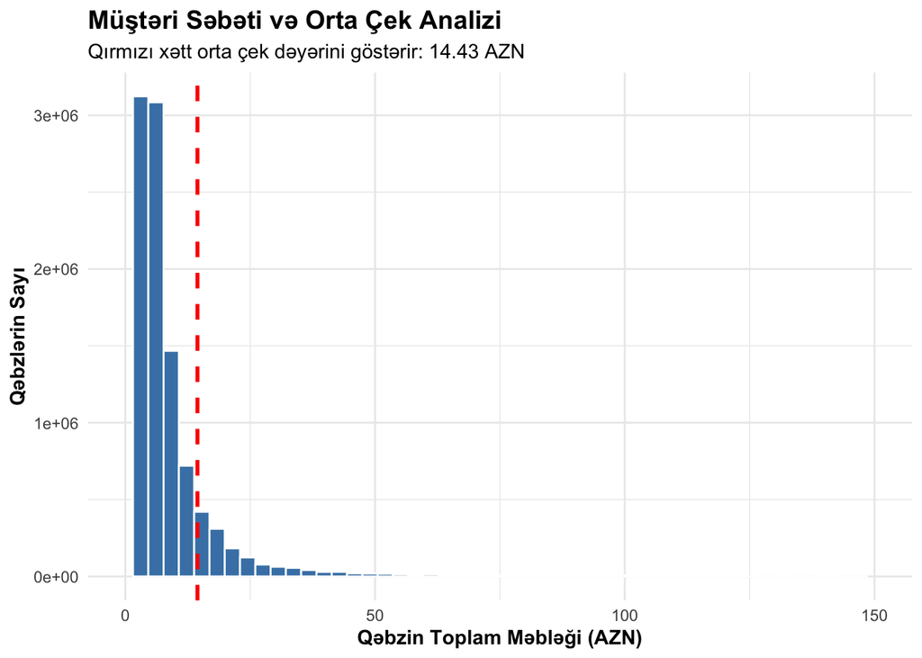

```r
ggplot(receipt_sums, aes(x = Total_Receipt_Value)) +
  geom_histogram(fill = "steelblue", color = "white", bins = 50) +
  xlim(0, 150) +
  geom_vline(aes(xintercept = average_ticket_size), color = "red", linetype = "dashed", size = 1) +
  theme_minimal() +
  labs(
    title = "Müştəri Səbəti və Orta Çek Analizi",
    subtitle = paste("Qırmızı xətt orta çek dəyərini göstərir:", round(average_ticket_size, 2), "AZN"),
    x = "Qəbzin Toplam Məbləği (AZN)",
    y = "Qəbzlərin Sayı"
  ) +
  theme(
    plot.title = element_text(face = "bold", size = 14),
    axis.title = element_text(face = "bold")
  )
```

**Şərh:** Müştəri səbəti və orta çek analizi göstərir ki, pərakəndə satış şəbəkəmizdə qəbzlərin məbləğ paylanması sağa meyllidir . Hesablamalara görə, riyazi orta çek dəyəri 14.43 AZN olsa da, daha real müştəri davranışını əks etdirən median çek dəyəri 6.2 AZN təşkil edir. Bu böyük fərq onu sübut edir ki, kütləvi müştəri axınımız əsasən kiçik məbləğli gündəlik tələbat alış-verişlərindən ibarətdir; lakin az sayda olan yüksək məbləğli böyük çeklər ümumi riyazi ortalamanı yuxarı çəkir. Biznes baxımından əsas hədəfimiz kiçik alış-veriş edən bu nəhəng müştəri kütləsinin səbətindəki məhsul sayını artırmaqla median çek dəyərini (6.2 AZN) yuxarı daşımaq olmalıdır.

```r
top10_sebet <- esas_data %>%
  group_by(pos) %>%
  summarise(
    sifaris_sayi = n_distinct(rec_id), # Sətir sayını yox, real unikal çek sayını tapırıq
    ortalama_sifaris_geliri = sum(gelir, na.rm = TRUE) / sifaris_sayi, # Ümumi gəliri çek sayına bölürük
    .groups = "drop"
  ) %>%
  arrange(desc(ortalama_sifaris_geliri)) %>%
  head(10)


knitr::kable(top10_sebet)
```

| pos | sifaris_sayi | ortalama_sifaris_geliri |
| --- | --- | --- |
| EMBAWOOD MEBEL SALONU | 9 | 52880.45 |
| ““BULGARY”” MAGAZASI | 11 | 44159.09 |
| IDEA-1 | 3 | 32905.47 |
| SLEEP ISTIKBAL | 9 | 18861.23 |
| TIFFANY | 6 | 15635.33 |
| ““ATLAS”” MEDICAL CENTER | 8 | 15132.58 |
| APTEK SABIRABAD 11 | 8 | 12976.99 |
| ““CHOPARD”” MAGAZASI | 9 | 12036.00 |
| INSAATCILAR MG | 87 | 11691.08 |
| ““ROYAL COLLECTION”” | 4 | 9378.00 |

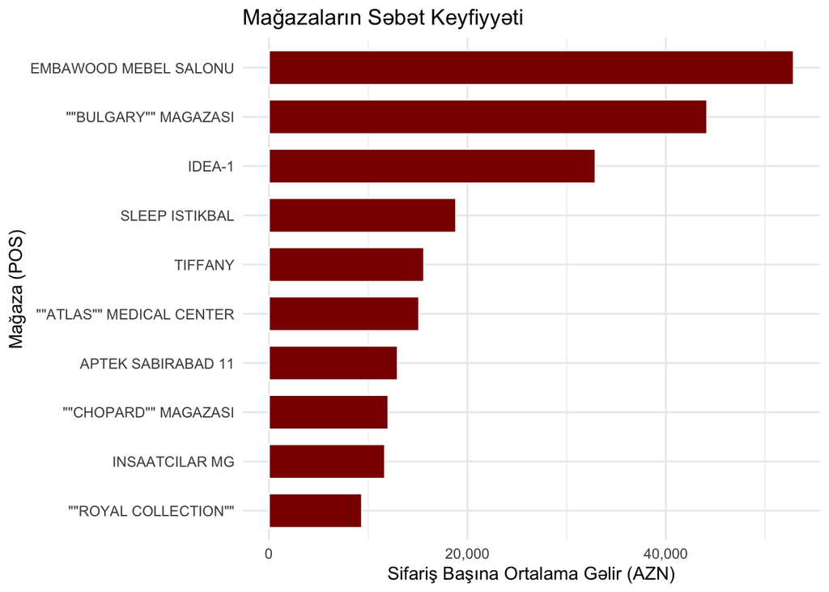

```r
ggplot(top10_sebet, aes(x = reorder(pos, ortalama_sifaris_geliri), y = ortalama_sifaris_geliri)) +
  geom_col(fill = "darkred", color = "white", width = 0.7) +
  coord_flip() +
  scale_y_continuous(labels = scales::comma) +
  labs(
    title = "Mağazaların Səbət Keyfiyyəti",
    x = "Mağaza (POS)",
    y = "Sifariş Başına Ortalama Gəlir (AZN)"
  ) +
  theme_minimal()
```

**Şərh:** Mağazaların səbət keyfiyyəti (sifariş başına ortalama gəlir) təhlili holdingin pərakəndə satışında fərqli biznes modellərinin gücünü ortaya qoyur. Ümumi gəlirdə marketlər lider olsa da, tək bir sifarişdən əldə edilən gəlirə görə lüks seqment və mebel qrupu öndədir. Analiz göstərir ki, “EMBAWOOD” mebel salonunda sifariş başına orta gəlir təxminən 50,000 AZN, “BULGARY” mağazasında isə 40,000 AZN-dən yüksəkdir.Bu nəticə sübut edir ki, holding pərakəndə fəaliyyətini iki fərqli sütun üzərində qurub: “Araz” və “Oba” kimi marketlər yüksək müştəri axını ilə böyük gəlir yaradır, “Embawood”, “Bulgary” və “Tiffany” kimi brendlər isə aşağı müştəri axınına rəğmən, nəhəng səbət dəyərləri (yüksək marja) ilə şirkətin ümumi gəlirliliyinə böyük töhfə verir.

## 2.9 Həftənin Günlərinə Görə Müştəri Davranışı (Mövsümilik)

Fərqli mağaza şəbəkələrində insanların həftə içi və ya həftə sonu daha çox xərcləmə etdiyini tapmaq marketinq kampaniyaları üçün kritikdir.

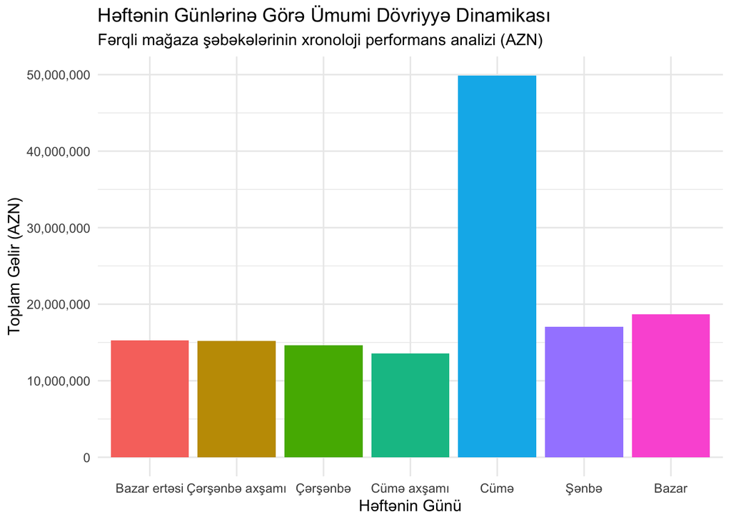

```r
gunler_data <- esas_data %>%
  mutate(gun_no = wday(rec_date, week_start = 1),
    gun_ad = case_when(
      gun_no == 1 ~ "Bazar ertəsi",
      gun_no == 2 ~ "Çərşənbə axşamı",
      gun_no == 3 ~ "Çərşənbə",
      gun_no == 4 ~ "Cümə axşamı",
      gun_no == 5 ~ "Cümə",
      gun_no == 6 ~ "Şənbə",
      gun_no == 7 ~ "Bazar"
    )
  ) %>%
  group_by(gun_ad, gun_no) %>%
  summarise(Toplam_Gelir = sum(gelir, na.rm = TRUE), .groups = 'drop') %>%
  arrange(gun_no) %>%
  mutate(gun_ad = factor(gun_ad, levels = gun_ad))

ggplot(gunler_data, aes(x = gun_ad, y = Toplam_Gelir, fill = gun_ad)) +
  geom_col() +
  scale_y_continuous(labels = scales::comma) +
  theme_minimal() +
  theme(
    legend.position = "none"
  ) +
  labs(
    title = "Həftənin Günlərinə Görə Ümumi Dövriyyə Dinamikası",
    subtitle = "Fərqli mağaza şəbəkələrinin xronoloji performans analizi (AZN)",
    x = "Həftənin Günü",
    y = "Toplam Gəlir (AZN)"
  )
```

**Şərh:** Həftəlik dövriyyə dinamikasına baxdıqda görünür ki, holdingin ən aktiv və gəlirli günü Cümə günüdür. Digər günlər orta hesabla 15 milyon AZN ətrafında sabit qaldığı halda, Cümə günü satışlar kəskin artaraq 50 milyon AZN-ə çatır. Bu, böyük ehtimalla Cümə gününə özəl keçirilən kütləvi kampaniyalar, həftəsonu öncəsi topdan tədarüklər və ya xüsusi endirim günləri ilə əlaqədardır.

## 2.10 Cümə günündəki gəlir artımının orta səbət dəyəri ilə deyil, tranzaksiya sayı ilə bağlılığının sübutu

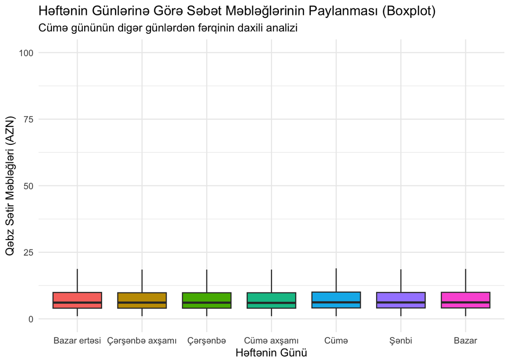

```r
boxplot_data <- esas_data %>%
  mutate(
    gun_no = wday(rec_date, week_start = 1),
    gun_ad = case_when(
      gun_no == 1 ~ "Bazar ertəsi",
      gun_no == 2 ~ "Çərşənbə axşamı",
      gun_no == 3 ~ "Çərşənbə",
      gun_no == 4 ~ "Cümə axşamı",
      gun_no == 5 ~ "Cümə",
      gun_no == 6 ~ "Şənbi",
      gun_no == 7 ~ "Bazar"
    )
  ) %>%
  mutate(gun_ad = factor(gun_ad, levels = unique(gun_ad[order(gun_no)])))
# Qeyd: Çox böyük lüks satışlar qrafiki korlamasın deyə y oxunu 0-100 AZN arası limitləyirik
ggplot(boxplot_data, aes(x = gun_ad, y = gelir, fill = gun_ad)) +
  geom_boxplot(outlier.shape = NA) + # Anomaliyaları (nöqtələri) gizlədirik ki, əsas qutu görünsün
  ylim(0, 100) +
  theme_minimal() +
  theme(legend.position = "none") +
  labs(
    title = "Həftənin Günlərinə Görə Səbət Məbləğlərinin Paylanması (Boxplot)",
    subtitle = "Cümə gününün digər günlərdən fərqinin daxili analizi",
    x = "Həftənin Günü",
    y = "Qəbz Sətir Məbləğləri (AZN)"
  )
```

## 2.11 Ən yüksək vahid qiyməti (unit_price) olan top 10 lüks məhsulu tapırıq

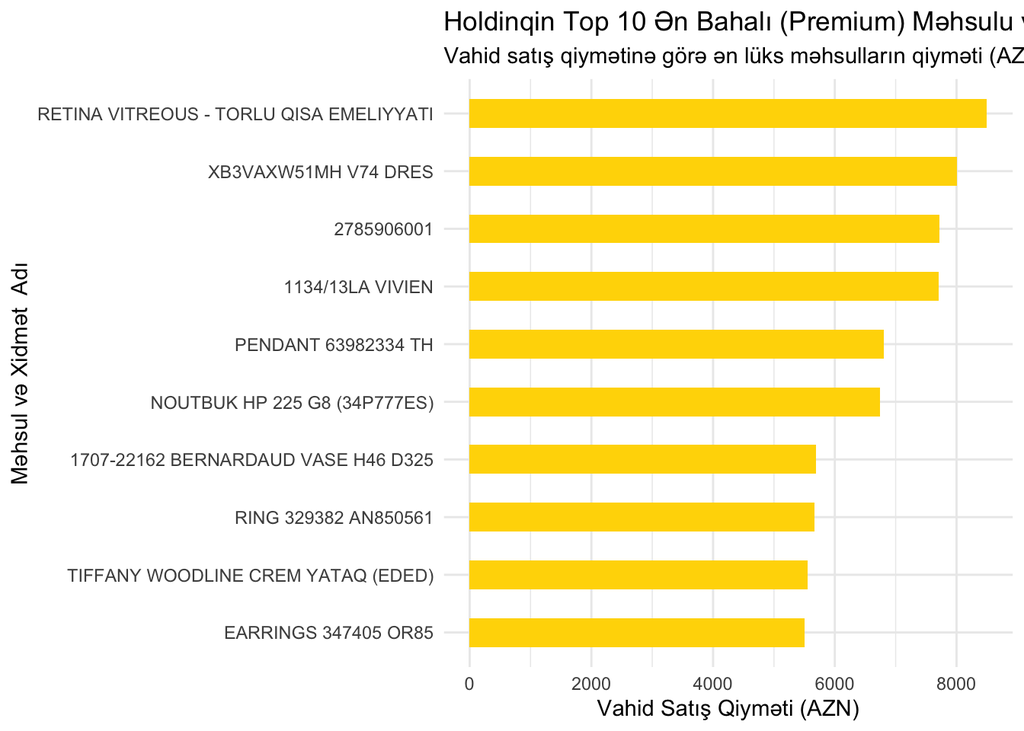

```r
# Qeyd: Qiymət xətası olan o məşhur 132,000 AZN-lik anomaliyanı filterlə kəsirik
luks_mehsullar <- esas_data %>%
  filter(unit_price < 10000) %>% # 10,000 AZN-dən yuxarı fantastik kassa xətalarını daxil etmirik
  group_by(product_name_clean) %>%
  summarise(
    Vahid_Qiymet = max(unit_price, na.rm = TRUE),
    Toplam_Satilan_Adet = sum(qnt, na.rm = TRUE)
  ) %>%
  arrange(desc(Vahid_Qiymet)) %>%
  slice_head(n = 10)

ggplot(luks_mehsullar, aes(x = reorder(product_name_clean, Vahid_Qiymet), y = Vahid_Qiymet)) +
  geom_col(fill = "gold", width = 0.5) + # Lüks mövzuya uyğun qızılı/qəhvəyi ton
  coord_flip() +
  theme_minimal() +
  labs(
    title = "Holdinqin Top 10 Ən Bahalı (Premium) Məhsulu və Xidməti",
    subtitle = "Vahid satış qiymətinə görə ən lüks məhsulların qiyməti (AZN)",
    x = "Məhsul və Xidmət  Adı",
    y = "Vahid Satış Qiyməti (AZN)"
  )
```

**Şərh:** Holdingin vahid satış qiymətinə görə top 10 ən bahalı məhsulunun analizi şirkətin səhiyyə, lüks geyim, zərgərlik və mebel kimi fərqli sahələrdə premium seqmentə xidmət etdiyini göstərir. Siyahının zirvəsində 8,000 AZN qiymətlə torlu qişa əməliyyatı yer alır; ardınca isə lüks libaslar, yataq dəstləri və zinət əşyaları gəlir. Bu premium məhsulların satış sayı az olsa da, mənfəət marjası çox yüksəkdir.Bu seqment üçün kütləvi reklamlar əvəzinə tam fərdiləşdirilmiş VIP marketinq strategiyası tətbiq edilməlidir. Xüsusilə lüks geyim və zərgərlik məhsullarında loyallığı artırmaq üçün fərdi sığorta, özəl çatdırılma və ya xüsusi baxım xidmətlərinin çarpaz satış (cross-selling) modeli ilə paket halında təklif olunması holdingin gəlirliliyini daha da dayanıqlı edəcəkdir.”

## 2.12 Şəbəkənin Ən Çox Zərər Etdiyi (Mənfi Marjalı) Məhsullar (İtki Yönümlü)

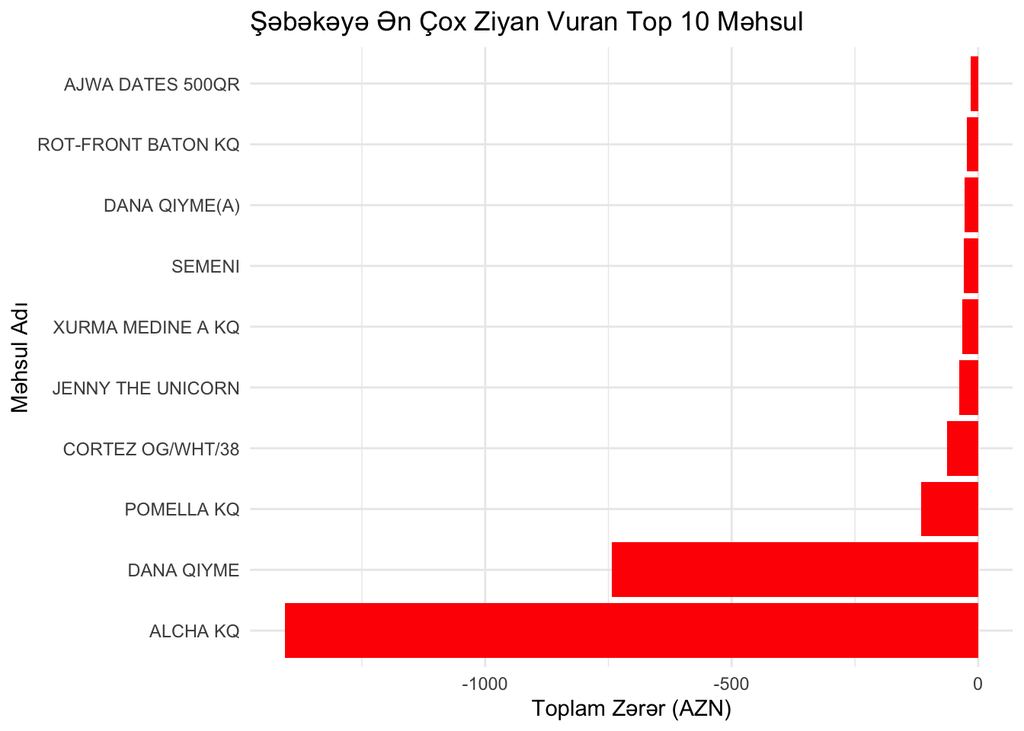

```r
zerer_edenler <- esas_data %>%
  filter(menfeet < 0) %>%
  group_by(product_name_clean) %>%
  summarise(Toplam_Zerer = sum(menfeet, na.rm = TRUE)) %>%
  arrange(Toplam_Zerer) %>% # Zatən mənfi olduğu üçün kiçikdən böyüyə sıralayırıq
  slice_head(n = 10)
ggplot(zerer_edenler, aes(x = reorder(product_name_clean, Toplam_Zerer), y = Toplam_Zerer)) +
  geom_col(fill = "red") +
  coord_flip() +
  theme_minimal() +
  labs(
    title = "Şəbəkəyə Ən Çox Ziyan Vuran Top 10 Məhsul",
    x = "Məhsul Adı",
    y = "Toplam Zərər (AZN)"
  )
```

**Şərh:** Mənfi marjalı məhsulların analizi göstərir ki, şəbəkəyə ən çox ziyan vuran məhsul kəskin fərqlə ‘Alcha KQ’ və ikinci yerdə ‘Dana Qiyme’-dir. Digər məhsulların vurduğu zərər bu ikisi ilə müqayisədə olduqca minimaldır. Alça və ət kimi pərakəndə məhsullarda zərərin bu qədər yüksək olması, çox güman ki, yüksək xarab olma/tələf olma dərəcəsi, yanlış qiymətləndirmə strategiyası və ya bu məhsulların müştəri cəlb etmək üçün zərərinə satış aləti kimi istifadə edilməsindən qaynaqlanır.Başda alça və ət məhsulları olmaqla, bu kateqoriyalarda anbar və logistika zəncirindəki itkilər minimuma endirilməli, tədarük həcmi gündəlik tələbə uyğun optimallaşdırılmalıdır. Əgər bu məhsullar mağazaya müştəri çəkmək üçün qəsdən zərərinə satılırsa, itkini kompensasiya etmək məqsədilə onların yanında yüksək marjalı çarpaz məhsulların yerləşdirilməsi və ya qiymət modelinin yenidən nəzərdən keçirilməsi tövsiyə olunur.

## 2.13 Heatmap

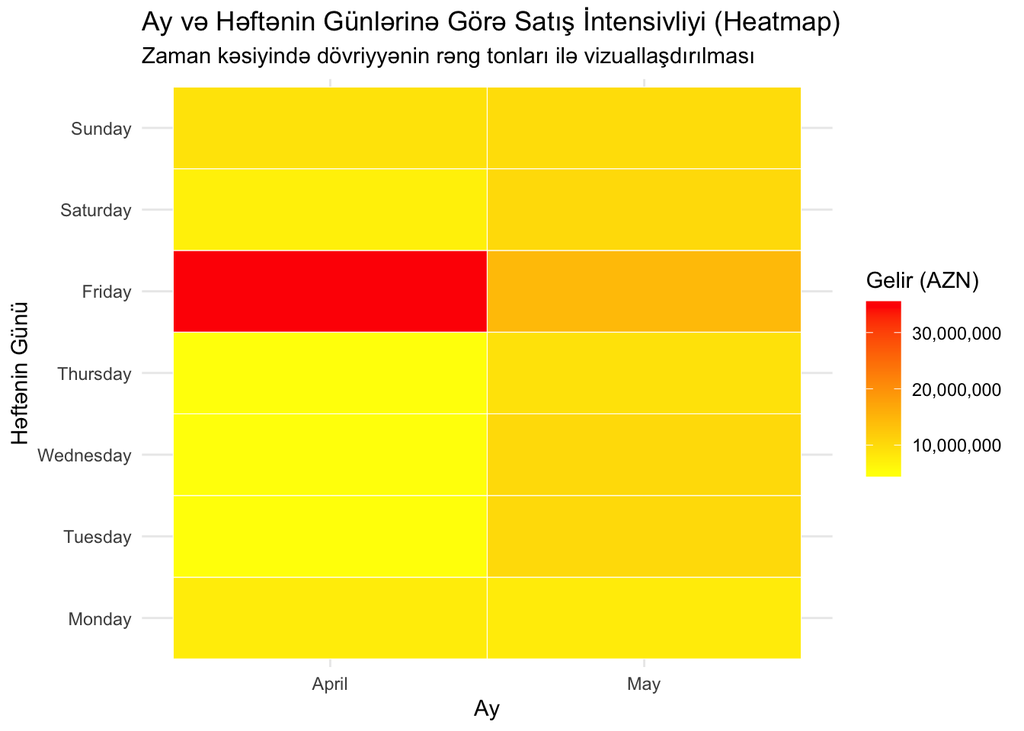

```r
# 1. Datadan ayları və günləri çıxarıb qruplaşdırırıq
heat <- esas_data %>%
  mutate(
    Ay = month(rec_date, label = TRUE, abbr = FALSE),
    Gun = wday(rec_date, label = TRUE, abbr = FALSE, week_start = 1) # Azərbaycan təqviminə uyğunlaşdırıldı
  ) %>%
  group_by(Ay, Gun) %>%
  summarise(Gelir = sum(gelir, na.rm = TRUE), .groups = "drop")
# 2. Heatmap (İstilik xəritəsi) qrafikinin qurulması
ggplot(heat, aes(x = Ay, y = Gun, fill = Gelir)) +
  geom_tile(color = "white") +
  scale_fill_gradient(
    low = "yellow",
    high = "red",
    labels = scales::comma
  ) +
  labs(
    title = "Ay və Həftənin Günlərinə Görə Satış İntensivliyi (Heatmap)",
    subtitle = "Zaman kəsiyində dövriyyənin rəng tonları ilə vizuallaşdırılması",
    x = "Ay",
    y = "Həftənin Günü",
    fill = "Gelir (AZN)"
  ) +
  theme_minimal()
```

## 2.14 Müştəri Səbət Məbləğlərinin Paylanma Strukturu

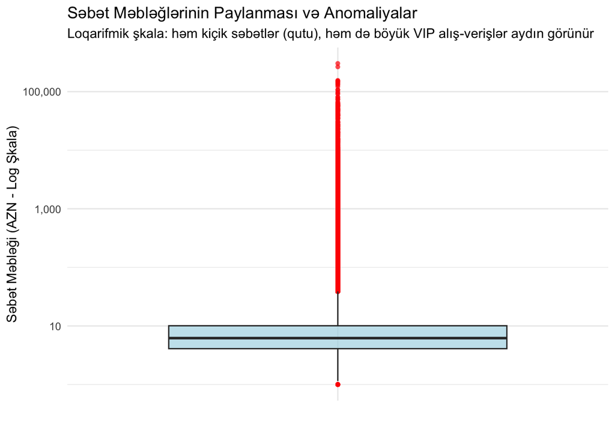

```r
sebet_gelirleri <- esas_data %>%
  group_by(rec_id) %>%
  summarise(Sebet_Meblegi = sum(gelir, na.rm = TRUE))

ggplot(sebet_gelirleri, aes(y = Sebet_Meblegi, x = "")) +
  geom_boxplot(fill = "lightblue", outlier.color = "red", outlier.shape = 16, outlier.size = 1.5, alpha = 0.7) +
  scale_y_log10(labels = scales::comma) +
  theme_minimal() +
  labs(
    title = "Səbət Məbləğlərinin Paylanması və Anomaliyalar",
    subtitle = "Loqarifmik şkala: həm kiçik səbətlər (qutu), həm də böyük VIP alış-verişlər aydın görünür",
    y = "Səbət Məbləği (AZN - Log Şkala)",
    x = ""
  )
```

# 3-CI HISSE: *Anomaliyalar*

## 3.1 Qeyri-adi yüksək ‘qnt’

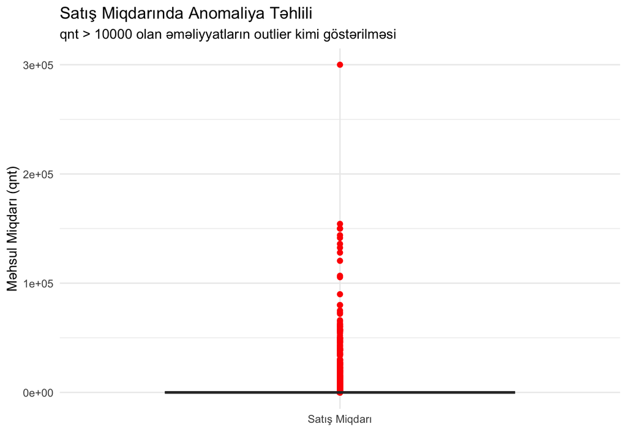

```r
ggplot(esas_data, aes(x = "Satış Miqdarı", y = qnt)) +
  geom_boxplot(outlier.colour = "red", outlier.shape = 16, outlier.size = 2) +
  theme_minimal() +
  labs(
    title = "Satış Miqdarında Anomaliya Təhlili",
    subtitle = "qnt > 10000 olan əməliyyatların outlier kimi göstərilməsi",
    x = "",
    y = "Məhsul Miqdarı (qnt)"
  )
```

**Şərh:** Satış miqdarı (qnt) üzrə apardığımız statistik təhlil zamanı boxplot vasitəsilə ümumi paylanmadan kəskin şəkildə fərqlənən bir sıra dəyərlər aşkar edilmişdir. Statistik baxımdan bu müşahidələr normal paylanma hüdudlarından kənara çıxdığı üçün ‘outlier’ kimi qeydə alınmışdır. Lakin biznes kontekstində bu rəqəmlər adi pərakəndə satış məntiqinə zidd olduğu üçün, onları ‘biznes anomaliyası’ olaraq təsnif etdik. Belə ki, 214 satış əməliyyatında məhsul miqdarının 10,000-dən 300,000-ə qədər yüksəlməsi ya sistemdəki texniki bir kodlaşdırma xətasından, ya da toplu satış əməliyyatlarının pərakəndə sisteminə yanlış daxil edilməsindən qaynaqlana bilər. Bu müşahidələrin analizin ümumi obyektivliyini pozmaması və satış performansının düzgün qiymətləndirilməsi üçün onları xüsusi nəzarətdə saxlayaraq, layihədə anomaliya kimi qruplaşdırdıq və ayrı-ayrı tədqiq etdik.

## 3.2 Məlumatın əhatə etdiyi tarix aralığı

```r
class(esas_data$rec_date)
```

```
## [1] "Date"
```

```r
min(esas_data$rec_date)
```

```
## [1] "2024-04-19"
```

```r
max(esas_data$rec_date)
```

```
## [1] "2024-05-31"
```

```r
table(year(esas_data$rec_date))
```

```
##
##     2024
## 10000909
```

```r
table(month(esas_data$rec_date))
```

```
##
##       4       5
## 5065915 4934994
```

**Şərh:** Məlumatlar yalnız bir ilin məhdud dövrünü əhatə etdiyi üçün illər üzrə müqayisə aparılmamışdır. Satış dinamikası günlər üzrə təhlil edilmişdir.

## 3.3 Günlük satışların aqreqasiyası

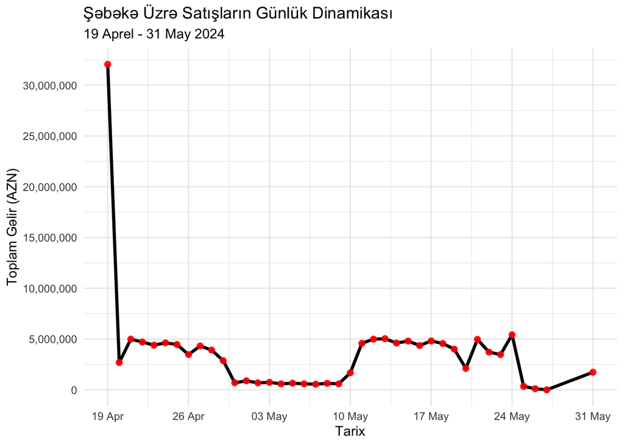

```r
trend_data <- esas_data %>%
  group_by(rec_date) %>%
  summarise(Gelir = sum(gelir, na.rm = TRUE))
ggplot(trend_data, aes(x = rec_date, y = Gelir)) +
  geom_line(color = "black", linewidth = 1.2) +
  geom_point(color = "red", size = 2, alpha = 0.9) +
  scale_y_continuous(labels = scales::comma, breaks = seq(0, 30000000, by = 5000000)) +
  scale_x_date(
  limits = c(as.Date("2024-04-19"), as.Date("2024-05-31")),
  breaks = seq(as.Date("2024-04-19"), as.Date("2024-05-31"), by = "7 days"),
  date_labels = "%d %b") +
  theme_minimal() +
  labs(
    title = "Şəbəkə Üzrə Satışların Günlük Dinamikası",
    subtitle = "19 Aprel - 31 May 2024 ",
    x = "Tarix", y = "Toplam Gəlir (AZN)"
  )
```

**Şərh:** Bu qrafik zaman oxu boyunca baş verən fəaliyyətləri əks etdirir və özündə həm sistem anomaliyalarını (texniki xətaları), həm də real biznes dinamikasını birləşdirir. Datanın başladığı ilk gün olan 19 aprel tarixində günlük gəlirin birdən-birə 30 milyon AZN həddini aşması normal satış fəaliyyəti deyil və bu sıçrayış əvvəlki analizlərdə aşkar etdiyimiz Ege Hospital kimi iri avans ödənişlərinin və digər köhnə sistem qeydlərinin bazaya ilk günün tarixi ilə kütləvi şəkildə yazılmasından yaranan sistem anomaliyasıdır. Eyni zamanda, may ayının ilk həftəsində gəlirin kəskin şəkildə minimuma enməsi və 2–9 may tarixləri arasında təxminən bir həftə boyunca tamamilə düz bir xətt üzrə sabit qalması da pərakəndə satış məntiqinə ziddir. Bu dövr real müştəri davranışını deyil, sistemdə baş vermiş texniki fasiləni, yəni məlumat axınının dayanmasını və ya server xətasını göstərən digər bir sistem anomaliyasıdır. Sözügedən bu iki anomal dövrü kənara qoyduqda isə şəbəkəmizin real günlük satış dövriyyəsinin çox stabil və sağlam formada 3-6 milyon AZN aralığında davam etdiyini görürük. Yekun qərar olaraq, 19 aprel sıçrayışı və 2–9 may tarixləri gələcək proqnozlaşdırma modelləri qurularkən və ya ümumi hesabatlar hazırlanarkən sistem xətası kimi qəbul edilməli və orta göstəriciləri korlamaması üçün datadan mütləq təmizlənməlidir.

## 3.5 Aşağı satış olan tarixin yoxlanılması

```r
may27_data = esas_data %>% filter(rec_date == as.Date("2024-05-27"))

dim(may27_data)
```

```
## [1]  1 12
```

```r
datatable(may27_data)
```

|  | pos | rec_date | rec_id | product_name | qnt | unit_price | period | product_name_clean | product_type | profit_margin | gelir | menfeet |
| --- | --- | --- | --- | --- | --- | --- | --- | --- | --- | --- | --- | --- |
| 1 | NGA KOROGLU BRAVO | 2024-05-27 | NGA_9849492 | TESS CAY DETOX 20ED | 2 | 3.49 | 202405 | TESS CAY DETOX 20ED |  |  | 6.98 |  |

```r
sum(may27_data$gelir, na.rm = TRUE)
```

```
## [1] 6.98
```

```r
summary(may27_data$gelir)
```

```
##    Min. 1st Qu.  Median    Mean 3rd Qu.    Max.
##    6.98    6.98    6.98    6.98    6.98    6.98
```

**Şərh:** Günlük gəlir qrafikində diqqət çəkən digər mühüm dalğalanma 27 may 2024-cü il tarixində qeydə alınan kəskin azalmadır. Bu enişin təbii bazar davranışından, yoxsa texniki sistem xətasından qaynaqlandığını müəyyən etmək üçün həmin günün satış tranzaksiyalarını dərindən analiz etdikdə çox maraqlı bir faktla qarşılaşırıq. Belə ki, milyonlarla sətirlik nəhəng bazada normalda hər gün on minlərlə əməliyyat aparıldığı halda, 27 may tarixində sistemə cəmi bir neçə məhsul satışı (Tess çayı) qeyd edilmişdir. Bu vizual sübut bizə deyir ki, həmin gün müştərilər alış-verişi dayandırmayıb, sadəcə olaraq satış terminalında və ya mərkəzi serverdə baş vermiş texniki qəza səbəbindən məlumatlar bazaya inteqrasiya olunmamışdır. Yekun olaraq, 27 may tarixinə aid bu süni eniş real biznesin gəlir performansını əks etdirməyən növbəti bir sistem-ötürmə anomaliyası kimi qiymətləndirilməli və analizin ümumi obyektivliyini qorumaq üçün nəzərə alınmalıdır.

## 3.6 Ən yüksək 10 satış əməliyyat

```r
top_sales =esas_data %>% arrange(desc(gelir))

datatable(top_sales %>% select(pos,product_name,qnt,unit_price,gelir) %>% head(10))
```

|  | pos | product_name | qnt | unit_price | gelir |
| --- | --- | --- | --- | --- | --- |
| 1 | EMBAWOOD MEBEL SALONU | Stol stul (ed) | 300001 | 1.01 | 303001.01 |
| 2 | ""BULGARY"" MAGAZASI | 356124 CL858599 CL M | 2 | 132301 | 264602 |
| 3 | MADAME COCO | MadamCoco (Ed) | 154301 | 1.01 | 155844.01 |
| 4 | OPTIMAL | Soyuducu LG (Ədəd) | 150001 | 1.01 | 151501.01 |
| 5 | EGE HOSPITAL | XÉstÉdÉn AvansÂ | 150001 | 1.01 | 151501.01 |
| 6 | INSAATCILAR MG | YAMAHA (ƏDƏD) | 143901 | 1.01 | 145340.01 |
| 7 | EGE HOSPITAL | XÉstÉdÉn AvansÂ | 141501 | 1.01 | 142916.01 |
| 8 | EGE HOSPITAL | XÉstÉdÉn AvansÂ | 136001 | 1.01 | 137361.01 |
| 9 | OPTIMAL ELEKTRONIKS | Kondisioner CARRIER (Ədəd) | 132501 | 1.01 | 133826.01 |
| 10 | EGE HOSPITAL | XÉstÉdÉn AvansÂ | 128001 | 1.01 | 129281.01 |

```r
print(top_sales)
```

[output not shown]

[output cut: 37 more lines]

**Şərh:** Siyahıda yer alan 1, 3, 4, 5, 6, 7, 8, 9 və 10-cu sətirlər real pərakəndə satış fəaliyyətini əks etdirmir. Bu əməliyyatların hər birində vahid qiymətin standart olaraq 1.01 AZN qeyd edilməsi və satış miqdarının 130-300 min ədəd kimi qeyri-real həddə olması texniki inteqrasiya xətalarından xəbər verir. Xüsusilə Ege Hospital üzrə daxil olan iri həcmli avans ödənişləri sistem tərəfindən yanlış olaraq ucuz məhsulların kütləvi satışı kimi emal edilmişdir. Bu anomaliyalar ortalama statistik göstəriciləri (məsələn, orta səbət dəyərini) süni şəkildə çarpıtdığı üçün ümumi data bazasından mütləq təmizlənməlidir. Siyahıdakı 2-ci sətir (Bulgary Mağazası) isə tamamilə fərqli struktura malikdir. Burada vahid qiyməti 132,301 AZN olan lüks məhsuldan cəmi 2 ədəd satılmışdır. Bu tranzaksiya hər hansı sistem səhvi deyil, şirkətin lüks seqmentdə həyata keçirdiyi real və uğurlu bir satış əməliyyatıdır. Statistik olaraq ümumi kütlədən kəskin uzaqlaşdığı üçün outlier adlandırılır və gələcək marketinq strategiyalarında ayrıca ‘Lüks müştəri davranışı’ kimi tədqiq edilməlidir. Yekun Qərar: Datanın təmizliyini və analizlərin etibarlılığını təmin etmək məqsədilə, 1.01 AZN-lik süni sistem yazıları (anomaliyalar) əsas modellərdən silinməli, lüks satışlar (outliers) isə ümumi kütlədən təcrid edilərək fərdi şəkildə qiymətləndirilməlidir.

## 3.7 Ən yüksək satışlarda vahid qiymət və miqdar əlaqəsi

```r
top_sales_100 = esas_data %>% arrange(desc(gelir)) %>% head(100)

summary(top_sales_100$unit_price)
```

```
##      Min.   1st Qu.    Median      Mean   3rd Qu.      Max.
##      1.01      1.01      1.01   3507.96      1.01 132301.00
```

```r
summary(top_sales_100$qnt)
```

```
##    Min. 1st Qu.  Median    Mean 3rd Qu.    Max.
##       2   36514   46901   55564   60051  300001
```

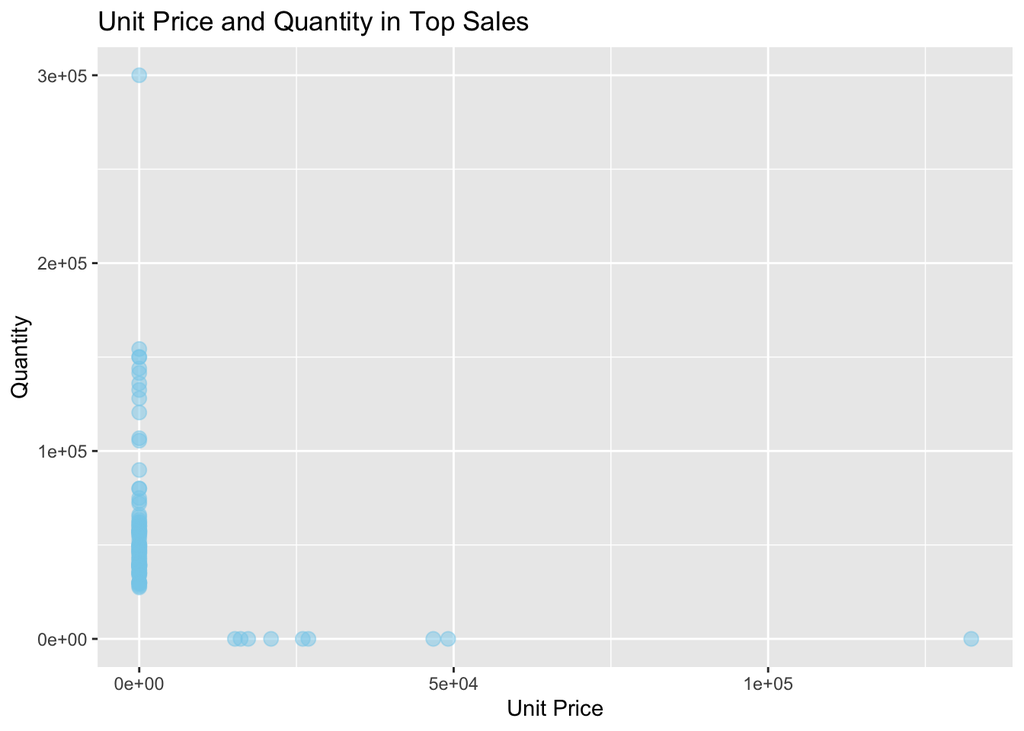

```r
ggplot(top_sales_100, aes(x = unit_price, y = qnt)) +
geom_point(color = "skyblue", size = 3, alpha = 0.5) +
labs(title = "Unit Price and Quantity in Top Sales", x = "Unit Price", y = "Quantity")
```

# 4-CI HISSE: *Proqnoz və Fərziyyələr*

## 4.1 Reqressiya modelinin qurulması

```r
model = lm(menfeet ~gelir + qnt + unit_price, data = fp_profit)

summary(model)
```

```
##
## Call:
## lm(formula = menfeet ~ gelir + qnt + unit_price, data = fp_profit)
##
## Residuals:
##     Min      1Q  Median      3Q     Max
## -628.26   -0.45   -0.10    0.26  370.76
##
## Coefficients:
##               Estimate Std. Error t value Pr(>|t|)
## (Intercept) -0.2298015  0.0065422  -35.13   <2e-16 ***
## gelir        0.2766454  0.0006935  398.90   <2e-16 ***
## qnt          0.1183061  0.0024996   47.33   <2e-16 ***
## unit_price  -0.0944529  0.0013867  -68.12   <2e-16 ***
## ---
## Signif. codes:  0 '***' 0.001 '**' 0.01 '*' 0.05 '.' 0.1 ' ' 1
##
## Residual standard error: 1.818 on 417650 degrees of freedom
## Multiple R-squared:  0.7397, Adjusted R-squared:  0.7397
## F-statistic: 3.956e+05 on 3 and 417650 DF,  p-value: < 2.2e-16
```

**Şərh:** Qurduğum model göstərir ki, gəlir və miqdar mənfəətə müsbət təsir edir, lakin vahid qiymətinin artması mənfəəti azaldır. Bütün amillər statistik olaraq əhəmiyyətlidir.

## 4.2 Market Basket Analizi

```r
hicaz_data <- esas_data %>%
  filter(grepl("HICAZ", toupper(product_name_clean)))
basket_analysis <- hicaz_data %>%
  pairwise_cor(item = product_name_clean, feature = rec_id, sort = TRUE)

final_basket <- basket_analysis %>%
  arrange(desc(correlation))



head(final_basket, 12)
```

```
## # A tibble: 12 × 3
##    item1                                item2               correlation
##    <chr>                                <chr>                     <dbl>
##  1 HICAZ TOYUQ FILE QABDA               SOSISKA HISLI HICAZ  -0.0000528
##  2 HICAZ KOLBASA HEVESKAR 1 KQ          SOSISKA HISLI HICAZ  -0.0000528
##  3 HICAZ TOYUQ QOSA KG                  SOSISKA HISLI HICAZ  -0.0000528
##  4 HICAZ SHEMS ELA NOV SOSISKA (CEKI)   SOSISKA HISLI HICAZ  -0.0000528
##  5 SOSIS HICAZ SUBH YEMEYI PACKA        SOSISKA HISLI HICAZ  -0.0000528
##  6 HICAZ LYUBITELSKAYA KG               SOSISKA HISLI HICAZ  -0.0000528
##  7 SOSIS HICAZ HISE VERILMISH CEKI      SOSISKA HISLI HICAZ  -0.0000528
##  8 HICAZ SALAFAN K                      SOSISKA HISLI HICAZ  -0.0000528
##  9 HICAZ VARYONIY KURIN KG              SOSISKA HISLI HICAZ  -0.0000528
## 10 HICAZ SAM YEMEYI SERVELAT KOLBASA KQ SOSISKA HISLI HICAZ  -0.0000528
## 11 HICAZ TOYUQ PAKET (CEKI)             SOSISKA HISLI HICAZ  -0.0000528
## 12 HICAZ FARS QABDA KQ                  SOSISKA HISLI HICAZ  -0.0000528
```

**Şərh:** Mağaza və Hicaz brendi üzrə apardığım geniş miqyaslı analiz məhsullar arasında statistik olaraq əhəmiyyətli birgə alınma tendensiyası aşkar etmədi.Korrelyasiya əmsallarının sıfıra yaxın olması müştərilərin konkret məhsul cütlüklərinə bağlı qalmadığını, daha çox spontan və fərdi seçim etdiyini sübut edir.Bu nəticə, mağazanın məhsul portfelində birgə alınma əsaslı kampaniyaların hazırda effektiv olmadığını göstərir.Merçendayzinq Rəflərin yerləşdirilməsində birgə alınma prinsipi deyil, müştəri axınını idarə edən və mağazanın daha çox hissəsini gəzməyə sövq edən strategiyalar tətbiq edilməlidir.Fərdiləşdirilmiş Kampaniyalar Standart A alana B endirimi əvəzinə, sadiqlik kartı məlumatlarına əsaslanan, müştərinin şəxsi vərdişlərinə uyğun təkliflər hazırlanmalıdır. Portfel Optimizasiyası Digər məhsullarla əlaqəsi olmayan və satışı zəif olan məhsulların çeşidi azaldılaraq anbar xərcləri optimallaşdırılmalıdır.Marketinq Strategiyası Büdcəni konkret məhsul cütlüklərini təşviq etməyə deyil, bütövlükdə brendin tanınırlığını və müştəri məmnuniyyətini artırmağa yönəltmək daha məqsədəuyğundur.

## 4.3 Qiymət və Satış Sayı arasında əlaqə

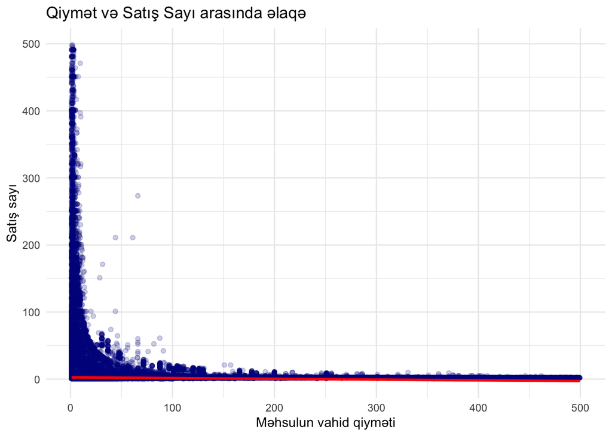

```r
plot_data <- esas_data %>%
  filter(unit_price < 500, qnt < 500)

ggplot(plot_data, aes(x = unit_price, y = qnt)) +
  geom_point(alpha = 0.2, color = "darkblue") +
  geom_smooth(method = "lm", color = "red", se = FALSE) +
  labs(title = "Qiymət və Satış Sayı arasında əlaqə",
       x = "Məhsulun vahid qiyməti",
       y = "Satış sayı") +
  theme_minimal()
```

**Şərh:** Aparılan qiymət həssaslığı analizi məhsulun vahid qiyməti ilə satış sayı arasında tərs mütənasib bir əlaqə olduğunu sübut edir.Qrafikdən aydın olur ki, məhsulların qiyməti artdıqca müştərilərin alış sayı kəskin şəkildə azalır, bu da istehlakçı davranışında qiymət faktorunun həlledici rol oynadığını göstərir. Biznes üçün əsas nəticə ondan ibarətdir ki, satış həcmini yüksək səviyyədə saxlamaq üçün qiymət strategiyası tənzimlənməli və əsas gəlir mənbəyi olan münasib qiymətli məhsulların stok nəzarəti gücləndirilməlidir. Bu nəticə marketin gələcək endirim və kampaniya strategiyalarının daha çox aşağı və orta qiymət seqmentindəki məhsullar üzərində qurulmasının vacibliyini təsdiqləyir.

# *Xülasə*

Bu layihədə satış məlumatları əsaslı şəkildə analiz olundu. İlk mərhələdə məlumatlar təmizlənərək təhlilə hazır vəziyyətə gətirildi və müvafiq cədvəllər birləşdirildi. Aparılan analizlər nəticəsində məhsul qiymətləri ilə satış həcmi arasındakı əlaqə müəyyən edildi və müştəri davranışının qiymətə olan həssaslığı üzə çıxarıldı. Eyni zamanda bazarın səmərəliliyini ölçmək üçün məhsullararası əlaqələr araşdırıldı. Ümumilikdə əldə olunan nəticələr mağazanın satış strategiyasının optimallaşdırılması, qiymət siyasətinin tənzimlənməsi və gələcək marketinq qərarlarının daha dəqiq qəbul edilməsi üçün strateji yol xəritəsi təqdim edir.